# `Project 7 - Computer Vision`

# 5. Fit and evaluate model and print confusion matrix (10 marks)

```python
# Fit the model #3
history_3=model_3.fit( x=X_train, y=Y_train, batch_size=32, epochs=40, validation_split = 0.3,shuffle=True, verbose=1, callbacks=[callback,model_checkpoint]) #using the validation split suggested for this excercise
```

```
Epoch 00001: val_loss did not improve from 1.35374

Epoch 00002: val_loss did not improve from 1.35374

Epoch 00003: val_loss did not improve from 1.35374
```

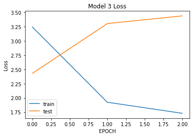

```python
# plot training history_3
plt.plot(history_3.history['loss'], label='train')
plt.plot(history_3.history['val_loss'], label='test')
plt.legend()
plt.title('Model 3 Loss')
plt.ylabel('Loss')
plt.xlabel('EPOCH')
plt.show()
```

## Final loss and accuracy

```python
# Score trained model # 1
scores_1 = model_1.evaluate(X_test, Y_test, verbose=1)
print('Test loss:', scores_1[0])
print('Test accuracy:', scores_1[1])
```

[output not shown]

```python
# Score trained model # 2
scores_2 = model_2.evaluate(X_test, Y_test, verbose=1)
print('Test loss:', scores_2[0])
print('Test accuracy:', scores_2[1])
```

```
Test loss: 2.422325372695923
Test accuracy: 0.1305263191461563
```

```python
# Score trained model # 3
scores_3 = model_3.evaluate(X_test, Y_test, verbose=1)
print('Test loss:', scores_3[0])
print('Test accuracy:', scores_3[1])
```

```
Test loss: 3.4527058601379395
Test accuracy: 0.1305263191461563
```

```python
from sklearn.metrics import classification_report, confusion_matrix
```

```python
y_pred = model_1.predict(X_test)
```

```python
y_pred.shape
```

```
(1425, 12)
```

```python
Y_test.shape
```

```
(1425, 12)
```

```python
label_dict
```

```
{0: 'Small-flowered Cranesbill',
 1: 'Fat Hen',
 2: 'Shepherds Purse',
 3: 'Common wheat',
 4: 'Common Chickweed',
 5: 'Charlock',
 6: 'Cleavers',
 7: 'Scentless Mayweed',
 8: 'Sugar beet',
 9: 'Maize',
 10: 'Black-grass',
 11: 'Loose Silky-bent'}
```

```
=== Confusion Matrix ===
```

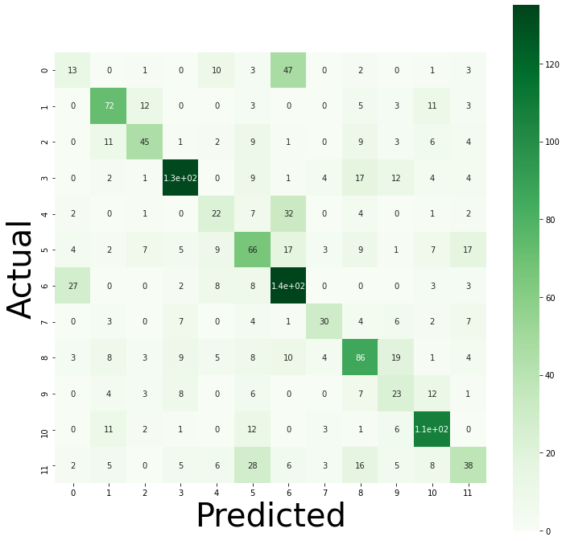

```python
Y_pred = np.argmax(y_pred, axis=1)
Y_true = np.argmax(Y_test, axis=1)

print("=== Confusion Matrix ===")
cm = confusion_matrix(Y_true, Y_pred)
plt.figure(figsize=(12, 12))
ax = sns.heatmap(cm, cmap=plt.cm.Greens, annot=True, square=True, xticklabels=label_dict, yticklabels=label_dict)
ax.set_ylabel('Actual', fontsize=40)
ax.set_xlabel('Predicted', fontsize=40)
```

```python
print("=== Classification Report ===")
print(classification_report(Y_true, Y_pred))
```

```
=== Classification Report ===
              precision    recall  f1-score   support

           0       0.25      0.16      0.20        80
           1       0.61      0.66      0.63       109
           2       0.60      0.49      0.54        91
           3       0.78      0.71      0.74       187
           4       0.35      0.31      0.33        71
           5       0.40      0.45      0.43       147
           6       0.54      0.73      0.62       186
           7       0.64      0.47      0.54        64
           8       0.54      0.54      0.54       160
           9       0.29      0.36      0.32        64
          10       0.66      0.75      0.70       144
          11       0.44      0.31      0.37       122

    accuracy                           0.54      1425
   macro avg       0.51      0.50      0.50      1425
weighted avg       0.54      0.54      0.53      1425
```

# 6. Visualize predictions for x_test[2], x_test[3], x_test[33], x_test[36], x_test[59]. (5 marks)

I will use the model_1 since it was the one that gave me better accuracy 0.54. However I believe that the models have to be corrected in order to get a better accuracy.

```
Predicted label: 6
Softmax Outputs: [[1.8731265e-05 2.0930478e-11 2.9848172e-06 2.7853864e-06 8.8833453e-04
  4.4023184e-04 9.9859565e-01 2.9898805e-13 5.0240706e-05 2.0404572e-10
  2.9938698e-07 7.9389787e-07]]
1.0000001
```

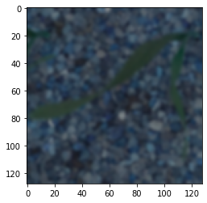

```python
import matplotlib.pyplot as plt
%matplotlib inline
plt.imshow(X_test[2].reshape(128, 128,3), cmap='gray')
y_pred = model_1.predict(X_test[2].reshape(1, 128, 128, 3))
print("Predicted label:", y_pred.argmax())
print("Softmax Outputs:", y_pred)
print(y_pred.sum())
```

```
Predicted label: 0
Softmax Outputs: [[9.9803573e-01 1.5252713e-20 1.3367345e-27 1.5568469e-17 7.5460302e-14
  7.9875964e-09 1.9642126e-03 5.2976112e-18 1.2577370e-17 1.3098766e-17
  1.1597038e-12 7.2697913e-17]]
0.99999994
```

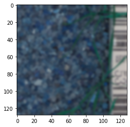

```python
import matplotlib.pyplot as plt
%matplotlib inline
plt.imshow(X_test[3].reshape(128, 128,3), cmap='gray')
y_pred = model_1.predict(X_test[3].reshape(1, 128, 128, 3))
print("Predicted label:", y_pred.argmax())
print("Softmax Outputs:", y_pred)
print(y_pred.sum())
```

```
Predicted label: 4
Softmax Outputs: [[1.1928395e-03 5.6970038e-08 3.2509467e-06 9.2884689e-10 8.1550705e-01
  7.8347297e-03 1.7496525e-01 8.6196735e-07 4.3913719e-04 2.9433405e-09
  4.3268309e-07 5.6434666e-05]]
1.0
```

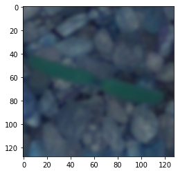

```python
import matplotlib.pyplot as plt
%matplotlib inline
plt.imshow(X_test[33].reshape(128, 128,3), cmap='gray')
y_pred = model_1.predict(X_test[33].reshape(1, 128, 128, 3))
print("Predicted label:", y_pred.argmax())
print("Softmax Outputs:", y_pred)
print(y_pred.sum())
```

```
Predicted label: 6
Softmax Outputs: [[5.8599126e-02 1.9563646e-13 1.5510361e-10 3.5040062e-09 1.3453348e-02
  2.9613072e-06 9.2771238e-01 5.5792315e-11 2.3225421e-04 6.1888034e-12
  2.8491391e-09 2.7397672e-08]]
1.0
```

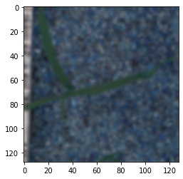

```python
import matplotlib.pyplot as plt
%matplotlib inline
plt.imshow(X_test[36].reshape(128, 128,3), cmap='gray')
y_pred = model_1.predict(X_test[36].reshape(1, 128, 128, 3))
print("Predicted label:", y_pred.argmax())
print("Softmax Outputs:", y_pred)
print(y_pred.sum())
```

```
Predicted label: 8
Softmax Outputs: [[1.9482126e-04 5.8497117e-11 3.1718320e-10 3.3819372e-08 3.5126266e-06
  3.1230073e-07 5.7862548e-05 5.4925238e-07 9.9951410e-01 3.6190208e-08
  1.6907468e-10 2.2879211e-04]]
1.0
```

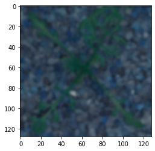

```python
import matplotlib.pyplot as plt
%matplotlib inline
plt.imshow(X_test[59].reshape(128, 128,3), cmap='gray')
y_pred = model_1.predict(X_test[59].reshape(1, 128, 128, 3))
print("Predicted label:", y_pred.argmax())
print("Softmax Outputs:", y_pred)
print(y_pred.sum())
```

# 7. CONCLUSIONS

## About Pre-Processing

- During the pre-processing of the data i found on internet 1 option called Mask, apparently it allows us to remove the background of the image. I did test it on this project but couldn't found the way to apply to all the data set. I left it in the project so i can have the reference for the future.
- I couldn't see the added value of applying Gausian Blurring. yes it remove the bightness of the images but still compared with the mask option, i think the blurring is not the best. Anyhow i moved forward with the data set after this filter.

## About making the data compatible

- Applying the reshap option in different stage of the porject helped to understand better the concept of the pixels and the array in 1-D( after falttening), 2-D (to plot the histogram of the pixels), and multiple channels which is the format needed in Keras.

## About Building the CNN

- For this project is the 1st time that i tried to build 3 model and try to compare the results in the accuracy. Unfortunately i couldn't get a high score for either of the 3 models.

-Unfortunately I run out of time and i could find where was the problem in my models, i suspect that was in the way the "history" of the model fit is saved, because every time i stopped and run all the code from the beggining, the result of plotting the history was different.

- I decided to use the same optimzer for all the modesl due to the lack of time and in this way I could concentrate in the layaring of the model.

-At the beggining I thought it could be a good idea since it is more realistic, as it was discussed in the menotr session. However, i didn't take in cosideration the possible error in handelling different models results. After I got severeal erros and very bad scores it was to late and I decided to keep the results to show my work.

- The main difference i wanted to explore was about the effect of the layaring in the model, and I took as references the models showed in the video lectuers and with the mentor. I was surprise that the model_1 which is the simplest gave higher score and that is the reason for which i think that there missing part in my process of trying different models because the model_3 was supposed to work better (as discussed in the last mentor session)
- At some point in this question i was about to delete the model_1 and model_2 and start all over only with the model_3, however since i invest a lot of time working on it i decided to present the results i got knowing that they can be improved.

## About fitting the data

- Since the performance of the model was poor, the plot of the history is showing overfitting.

## About the Confussion matrix

- Here we can see the reflect of having a model with 0.54 score.
- 7 clasess had a precission above 50 % using the model_1. I didn't try with the other models since I go an accuracy of 0.13 in both of them. -the main take away in this section is that it is possible to visualize the results using this option.
- I couldn't find the way to plot the name (labels) in the confussion matrix. I think it is possible but due to the lack of time i couldn't do a biggere research about it.

## About visualize the data

- It was done using the model_1.
- Since i was not able to plot the label name, it is hard to know if the image plotted is actually the one predicted.